# Introduction to Google Colab and PySpark

# Hands-on again!

**What is the most frequently reported non-criminal activity?**

**Find the day of the week with the most reported crime?**

**Using a bar chart, plot which day of the week has the most number of reported crime.**

```python
from pyspark.sql.functions import date_format, col
dow = [x[0] for x in df.groupBy(date_format(col('Date'),'E')).count().collect()]
print(dow)
cnt = [x[1] for x in df.groupBy(date_format(col('Date'),'E')).count().collect()]
print(cnt)
```

```
['Sun', 'Mon', 'Thu', 'Sat', 'Wed', 'Tue', 'Fri']
[20036, 21041, 20701, 21786, 20652, 21331, 22147]
```

```python
import pandas as pd
import matplotlib.pyplot as plt

cp = pd.DataFrame({'Day_of_week':dow, 'Count':cnt})
cp.head()
```

|  | Day_of_week | Count |
| --- | --- | --- |
| 0 | Sun | 20036 |
| 1 | Mon | 21041 |
| 2 | Thu | 20701 |
| 3 | Sat | 21786 |
| 4 | Wed | 20652 |

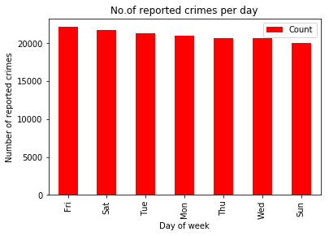

```python
cp.sort_values('Count', ascending=False).plot(kind='bar', color= 'red', x='Day_of_week', y='Count')
plt.xlabel("Day of week")
plt.ylabel("Number of reported crimes")
plt.title("No.of reported crimes per day")
```

# RDD

> With map, you define a function and then apply it record by record. Flatmap returns a new RDD by first applying a function to all of the elements in RDDs and then flattening the result. Filter, returns a new RDD. Meaning only the elements that satisfy a condition. With reduce, we are taking neighboring elements and producing a single combined result. For example, let's say you have a set of numbers. You can reduce this to its sum by providing a function that takes as input two values and reduces them to one.

```python
psrdd = sc.textFile('police-station.csv')
print(psrdd.first())
ps_header = psrdd.first()
ps_rest = psrdd.filter(lambda line: line!=ps_header)
print(ps_rest.first())
```

```
DISTRICT,DISTRICT NAME,ADDRESS,CITY,STATE,ZIP,WEBSITE,PHONE,FAX,TTY,X COORDINATE,Y COORDINATE,LATITUDE,LONGITUDE,LOCATION
1,Central,1718 S State St,Chicago,IL,60616,http://home.chicagopolice.org/community/districts/1st-district-central/,312-745-4290,312-745-3694,312-745-3693,1176569.052,1891771.704,41.85837259,-87.62735617,"(41.8583725929, -87.627356171)"
```

**How many police stations are there?**

```python
ps_rest.map(lambda line: line.split(",")).count()
```

```
24
```

**Display the District ID, District name, Address and Zip for the police station with District ID 7**

```python
# District is column  0
(ps_rest.filter(lambda line: line.split(",")[0]=='7').
 map(lambda line: (line.split(",")[0],
    line.split(",")[1],
    line.split(",")[2],
    line.split(",")[5])).collect())
```

```
[('7', 'Englewood', '1438 W 63rd St', '60636')]
```

**Police stations 10 and 11 are geographically close to each other. Display the District ID, District name, address and zip code**

```python
# District is column  0
(ps_rest.filter(lambda line: line.split(",")[0] in ['10', '11']).
 map(lambda line: (line.split(",")[0],
    line.split(",")[1],
    line.split(",")[2],
    line.split(",")[5])).collect())
```

```
[('11', 'Harrison', '3151 W Harrison St', '60612'),
 ('10', 'Ogden', '3315 W Ogden Ave', '60623')]
```